# Lab 1c. Species Distribution Modeling - Decision Trees

Julia Parish

2022/01/26

# Setup

```r
# read data
pts_env <- read_csv(pts_env_csv)
d <- pts_env %>%
  select(-ID) %>%                   # not used as a predictor x
  mutate(
    present = factor(present)) %>%  # categorical response
  na.omit()                         # drop rows with NA
skim(d)
```

Data summary

| Name | d |
| --- | --- |
| Number of rows | 19912 |
| Number of columns | 8 |
| _______________________ |  |
| Column type frequency: |  |
| factor | 1 |
| numeric | 7 |
| ________________________ |  |
| Group variables | None |

**Variable type: factor**

| skim_variable | n_missing | complete_rate | ordered | n_unique | top_counts |
| --- | --- | --- | --- | --- | --- |
| present | 0 | 1 | FALSE | 2 | 0: 9992, 1: 9920 |

**Variable type: numeric**

| skim_variable | n_missing | complete_rate | mean | sd | p0 | p25 | p50 | p75 | p100 | hist |
| --- | --- | --- | --- | --- | --- | --- | --- | --- | --- | --- |
| WC_alt | 0 | 1 | 655.63 | 700.14 | -76.00 | 94.00 | 291.00 | 1259.25 | 3648.00 | ▇▂▂▁▁ |
| WC_bio1 | 0 | 1 | 13.48 | 3.95 | -0.80 | 11.10 | 13.80 | 16.00 | 23.40 | ▁▂▆▇▁ |
| WC_bio2 | 0 | 1 | 13.57 | 2.99 | 6.10 | 11.20 | 13.90 | 16.10 | 21.30 | ▂▇▇▇▁ |
| ER_tri | 0 | 1 | 41.92 | 29.96 | 0.21 | 19.68 | 36.64 | 57.36 | 223.20 | ▇▅▁▁▁ |
| ER_topoWet | 0 | 1 | 10.38 | 1.34 | 6.83 | 9.44 | 10.32 | 11.15 | 15.04 | ▁▇▇▂▁ |
| lon | 0 | 1 | -119.03 | 3.90 | -124.55 | -122.25 | -120.12 | -117.03 | -106.46 | ▇▅▃▂▁ |
| lat | 0 | 1 | 37.18 | 3.37 | 30.21 | 34.31 | 37.41 | 38.57 | 47.29 | ▃▅▇▂▁ |

# Learning Objectives

There are two broad categories of Supervised Classification based on the type of response your modeling $y \sim x$, where $y$ is either a continuous value, in which case **Regression**, or it is a categorical value, in which case it’s a **Classification**.

A **binary** response, such as presence or absence, is a categorical value, so typically a Classification technique would be used. However, by transforming the response with a logit function, we were able to use Regression techniques like generalized linear (`glm()`) and generalized additive (`gam()`) models.

In this portion of the lab you’ll use **Decision Trees** as a **Classification** technique to the data with the response being categorical (`factor(present)`).

- **Recursive Partitioning** (`rpart()`)  
  Originally called classification & regression trees (CART), but that’s copyrighted (Breiman, 1984).
- **Random Forest** (`RandomForest()`)  
  Actually an ensemble model, ie trees of trees.

## Split data into training and testing

```r
# create training set with 80% of full data
d_split  <- rsample::initial_split(d, prop = 0.8, strata = "present")
d_train  <- rsample::training(d_split)

# show number of rows present is 0 vs 1
table(d$present)
```

```
##
##    0    1
## 9992 9920
```

```r
table(d_train$present)
```

```
##
##    0    1
## 7993 7936
```

# Decision Trees

Reading: Boehmke & Greenwell (2020) Hands-On Machine Learning with R. [Chapter 9 Decision Trees](https://bradleyboehmke.github.io/HOML/DT.html)

## Partition, depth=1

```r
# run decision stump model
mdl <- rpart(
  present ~ ., data = d_train,
  control = list(
    cp = 0, minbucket = 5, maxdepth = 1))
mdl
```

```
## n= 15929
##
## node), split, n, loss, yval, (yprob)
##       * denotes terminal node
##
## 1) root 15929 7936 0 (0.5017892 0.4982108)
##   2) WC_alt>=491.5 6449  250 0 (0.9612343 0.0387657) *
##   3) WC_alt< 491.5 9480 1794 1 (0.1892405 0.8107595) *
```

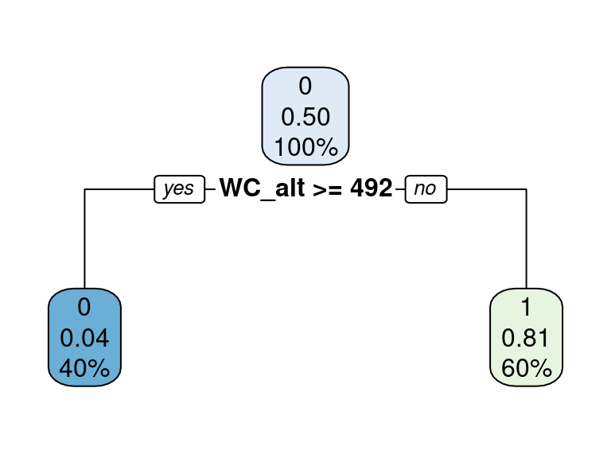

```r
# plot tree
par(mar = c(1, 1, 1, 1))
rpart.plot(mdl)
```

## Partition, depth=default

```r
# decision tree with defaults
mdl <- rpart(present ~ ., data = d_train)
mdl
```

```
## n= 15929
##
## node), split, n, loss, yval, (yprob)
##       * denotes terminal node
##
##  1) root 15929 7936 0 (0.501789190 0.498210810)
##    2) WC_alt>=491.5 6449  250 0 (0.961234300 0.038765700) *
##    3) WC_alt< 491.5 9480 1794 1 (0.189240506 0.810759494)
##      6) lon>=-116.8858 792    4 0 (0.994949495 0.005050505) *
##      7) lon< -116.8858 8688 1006 1 (0.115791897 0.884208103)
##       14) lat>=42.09659 501   76 0 (0.848303393 0.151696607) *
##       15) lat< 42.09659 8187  581 1 (0.070966166 0.929033834)
##         30) WC_bio2>=15.25 407  128 0 (0.685503686 0.314496314) *
##         31) WC_bio2< 15.25 7780  302 1 (0.038817481 0.961182519) *
```

```
##           CP nsplit  rel error    xerror        xstd
## 1 0.74243952      0 1.00000000 1.0132308 0.007951381
## 2 0.09879032      1 0.25756048 0.2579385 0.005322173
## 3 0.04397681      2 0.15877016 0.1595262 0.004301623
## 4 0.01902722      3 0.11479335 0.1161794 0.003713783
## 5 0.01000000      4 0.09576613 0.1001764 0.003463096
```

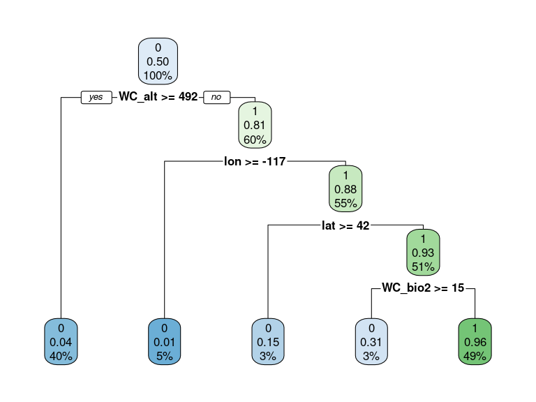

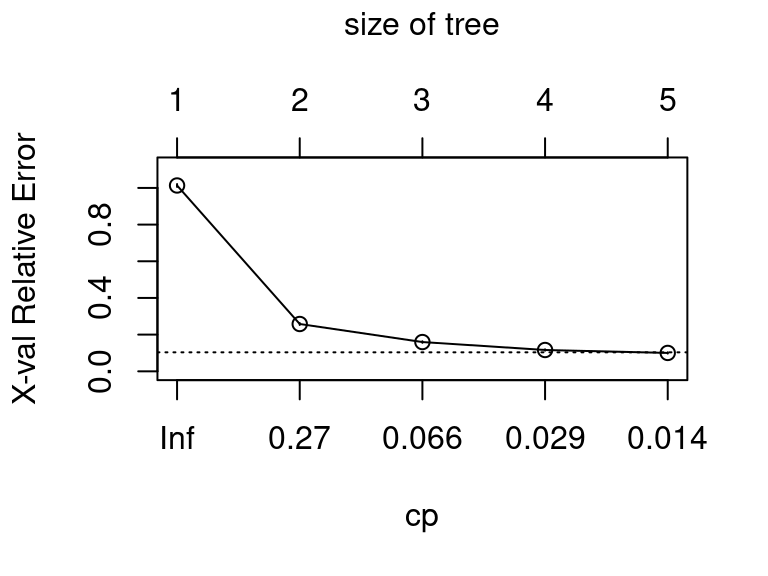

Decision tree $present$ classification.

```r
rpart.plot(mdl)

# plot complexity parameter
plotcp(mdl)

# rpart cross validation results
mdl$cptable
```

## Feature interpretation

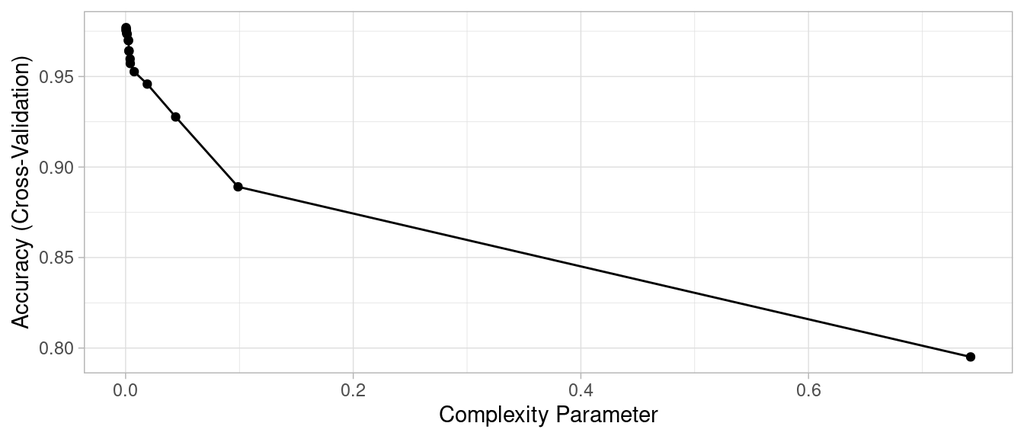

Cross-validated accuracy rate for the 20 different $\alpha$ parameter values in our grid search. Lower $\alpha$ values (deeper trees) help to minimize errors.

```r
# caret cross validation results
mdl_caret <- train(
  present ~ .,
  data       = d_train,
  method     = "rpart",
  trControl  = trainControl(method = "cv", number = 10),
  tuneLength = 20)

ggplot(mdl_caret)
```

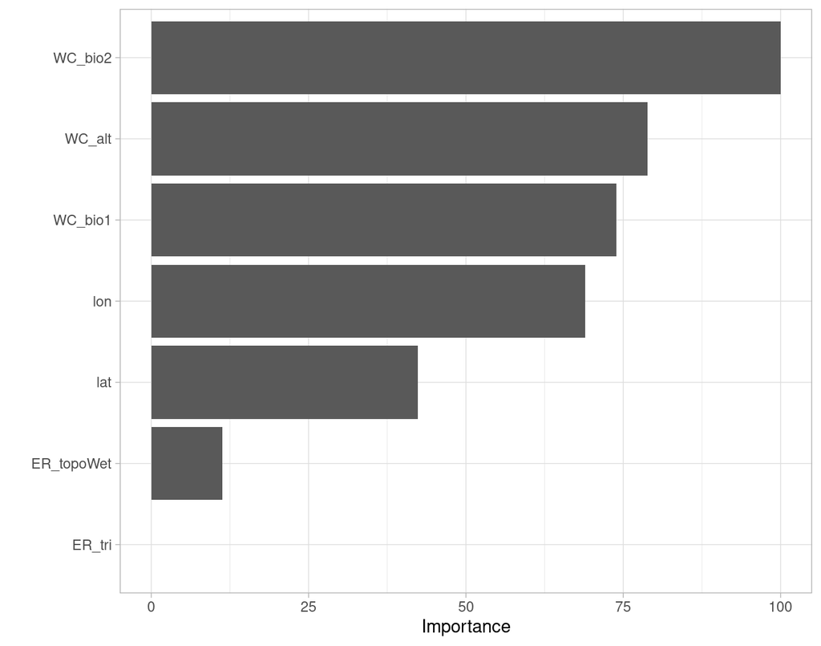

```r
vip(mdl_caret, num_features = 40, bar = FALSE)
```

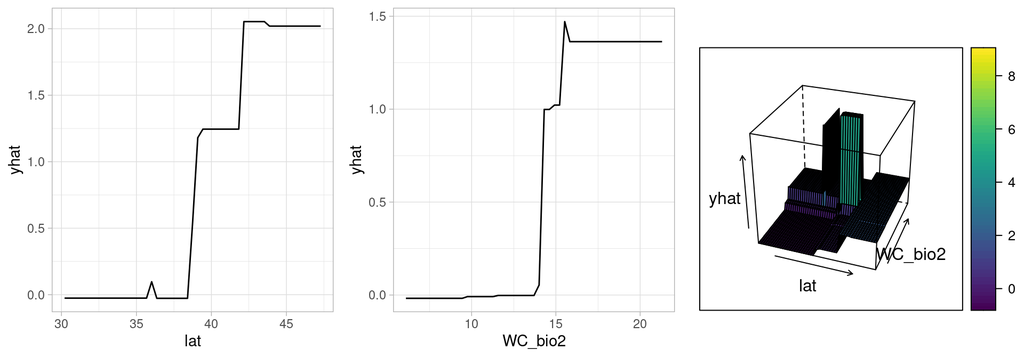

Partial dependence plots to understand the relationship between lat, WC_bio2 and present.

```r
# Construct partial dependence plots
p1 <- partial(mdl_caret, pred.var = "lat") %>% autoplot()
p2 <- partial(mdl_caret, pred.var = "WC_bio2") %>% autoplot()
p3 <- partial(mdl_caret, pred.var = c("lat", "WC_bio2")) %>%
  plotPartial(levelplot = FALSE, zlab = "yhat", drape = TRUE,
              colorkey = TRUE, screen = list(z = -20, x = -60))

# Display plots side by side
gridExtra::grid.arrange(p1, p2, p3, ncol = 3)
```

# Random Forests

Reading: Boehmke & Greenwell (2020) Hands-On Machine Learning with R. [Chapter 11 Random Forests](https://bradleyboehmke.github.io/HOML/random-forest.html)

See also: [Random Forest – Modeling methods | R Spatial](https://rspatial.org/raster/sdm/6_sdm_methods.html#random-forest)

## Fit

```r
# number of features
n_features <- length(setdiff(names(d_train), "present"))

# fit a default random forest model
mdl_rf <- ranger(present ~ ., data = d_train)

# get out of the box RMSE
(default_rmse <- sqrt(mdl_rf$prediction.error))
```

```
## [1] 0.1188494
```

## Feature interpretation

```r
# re-run model with impurity-based variable importance
mdl_impurity <- ranger(
  present ~ ., data = d_train,
  importance = "impurity")

# re-run model with permutation-based variable importance
mdl_permutation <- ranger(
  present ~ ., data = d_train,
  importance = "permutation")
```

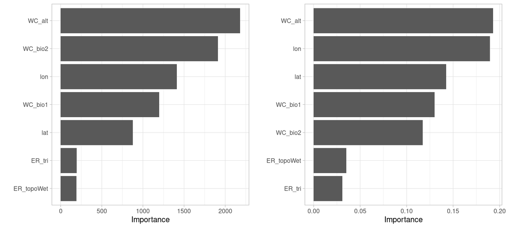

Most important variables based on impurity (left) and permutation (right).

```r
p1 <- vip::vip(mdl_impurity, bar = FALSE)
p2 <- vip::vip(mdl_permutation, bar = FALSE)

gridExtra::grid.arrange(p1, p2, nrow = 1)
```